# Visualise participants against model predictions for stability parameter 0

2024-10-10

This code combines participant and model predictions at stability parameter 0.

## How to read these charts

The blue dotted line in the plots is a baseline of 12.5%, that is, the chance level of a participant choosing any variable (they were permitted to choose any).

The red dashed line is a much more conservative baseline of equal choice between only those answers that were coherent with actual causation, i.e., if the outcome was 0 in a disjunctive setting, when A was 1 and B was 0, then the only two coherent explanations for outcome 0 are Au=0 and B=0, as it is meaningless for Bu to have any value when B=0, and we know Au=0 because otherwise the effect would have occurred. There are always two coherent explanations, except for when both A and B occurred and the outcome occurred, when there are four (shown by red dashed line at 0.25 in those conditions).

Incoherent answers were permitted and were occasionally chosen by participants, but these bars are shown very faintly.

## Model predictions are made up of…

Weighted averages of each probability group - here is group 1

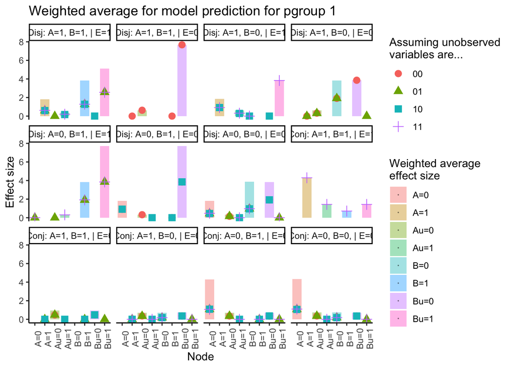

Weighted averages of each probability group - here is group 2

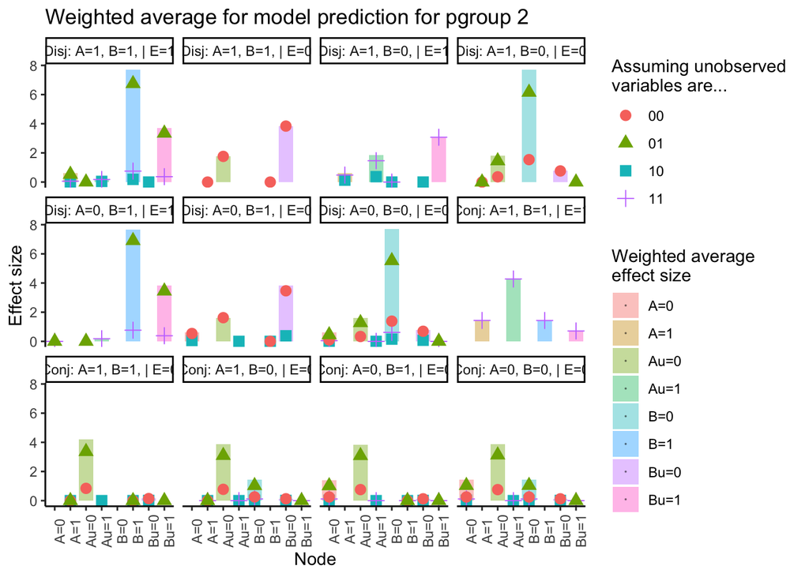

Weighted averages of each probability group - here is group 3

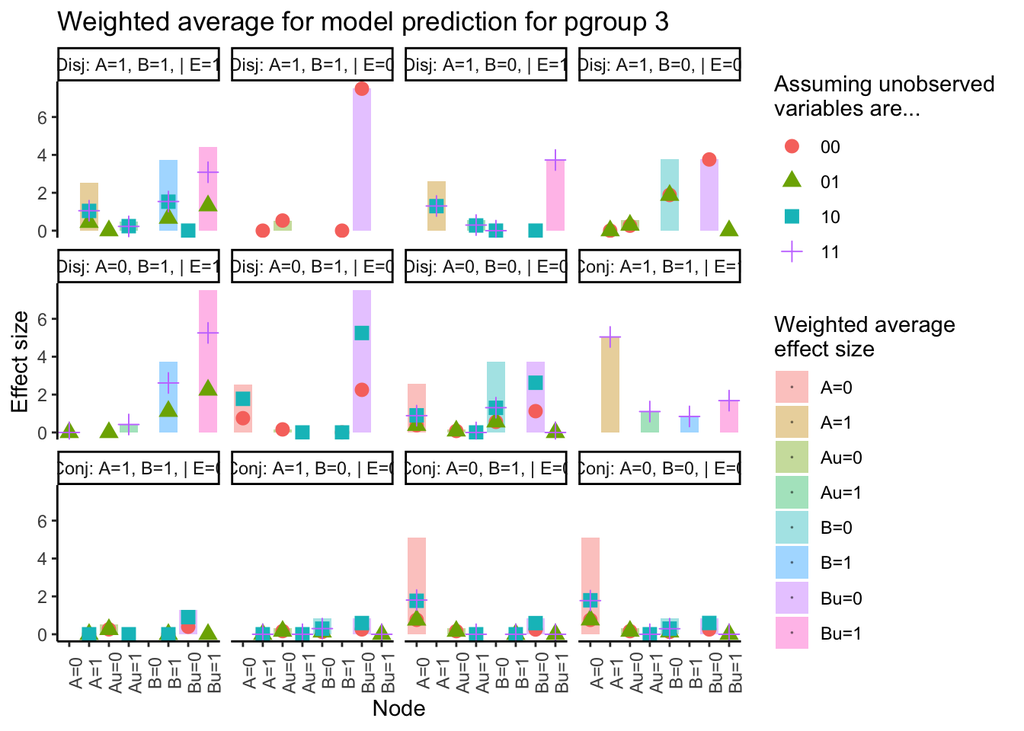

## All probgroups

Shown next to each other with position dodge - don’t like it much

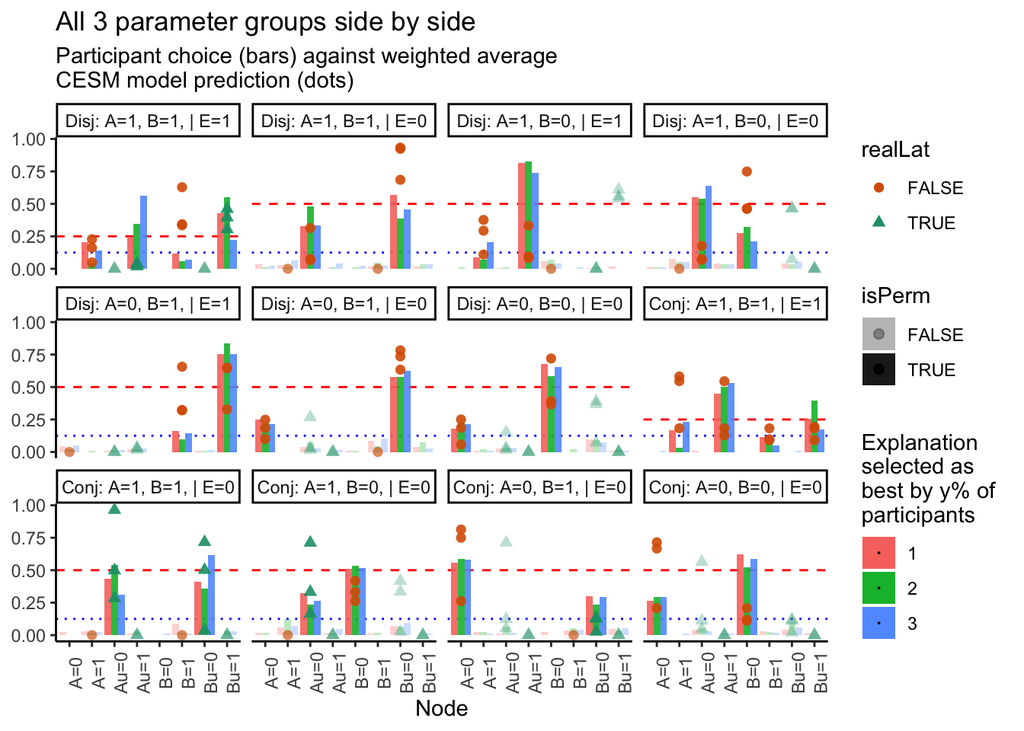

## Model predictions compared against participant data, split out by probability group

The first plot is probability group 1

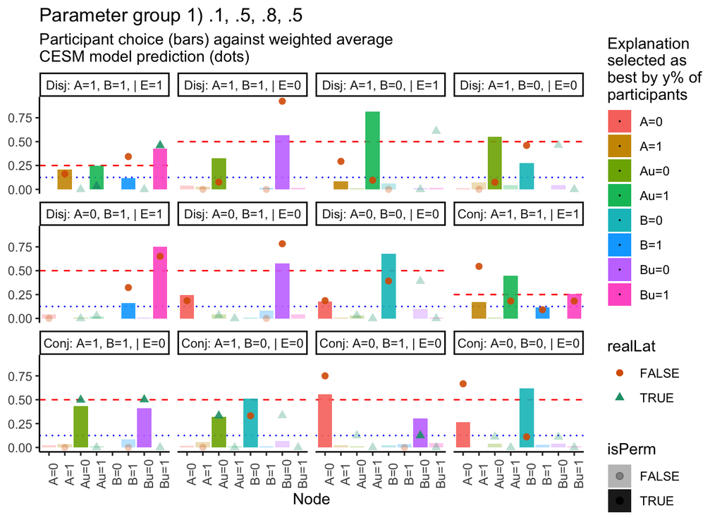

The second is probability group 2.

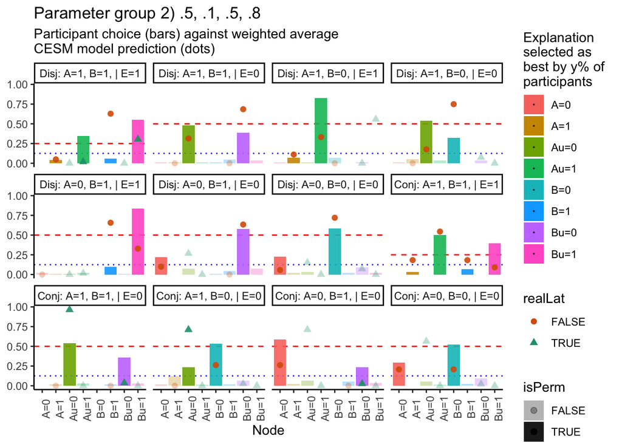

Now for probability group 3.

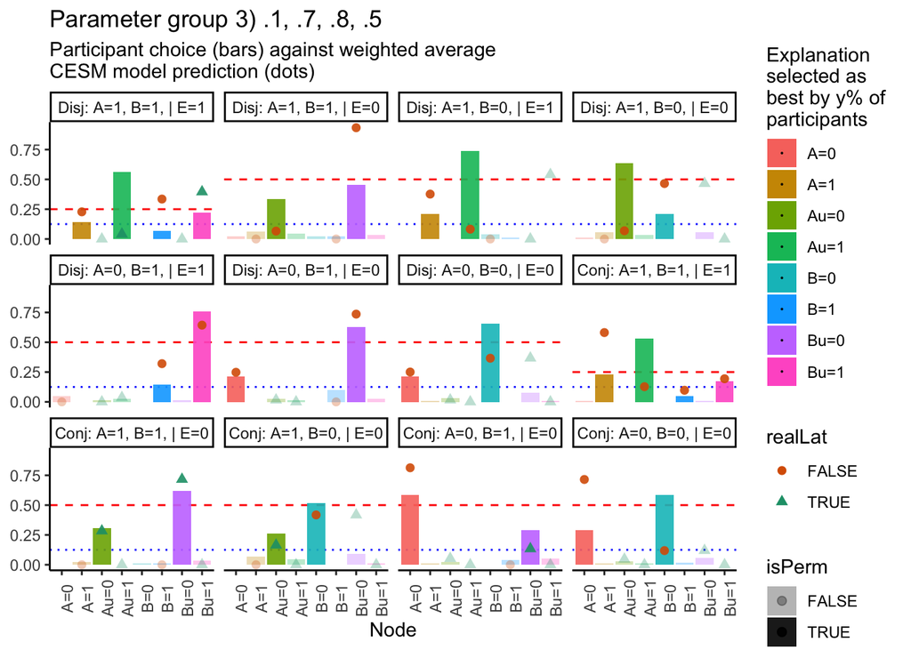

## Correlations

We want to check whether people’s judgements are less sensitive to the changing probs (param manipulation) than the model is? check statistically through cor(cond1-cond2) for ppts then model, then cor(cond2-3), then 1-3.

### Participants

Across the three parameter groups, the correlations for participants are: Group 1 to 2: 0.968. Group 1 to 3: 0.96. Group 2 to 3: 0.935.

### Model

Across the three parameter groups, the correlations for model are: Group 1 to 2: 0.674. Group 1 to 3: 0.979. Group 2 to 3: 0.56.

## Correlation to check model fit

This scatter plot is for all three probability settings, for just this value of s.

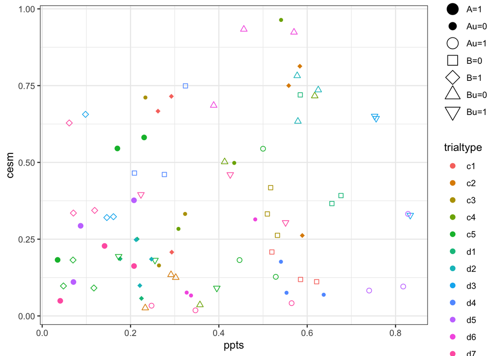

Then the important number is 0.221.

And one for the model preds 4, equal params 0.5 for everything.

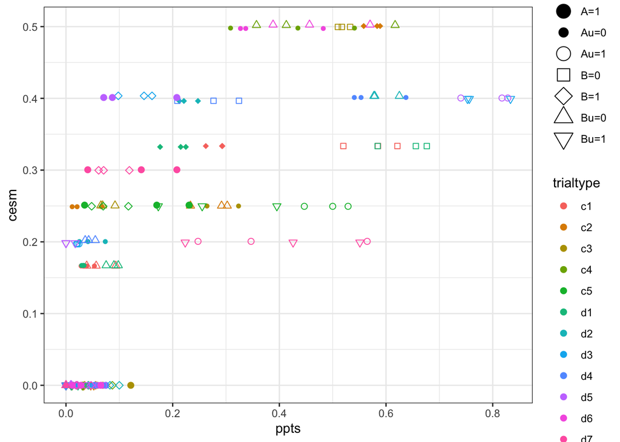

For THAT the important number is NA.

Let’s also split them out by probgroups…

### Parameter group 1) .1, .5, .8, .5.

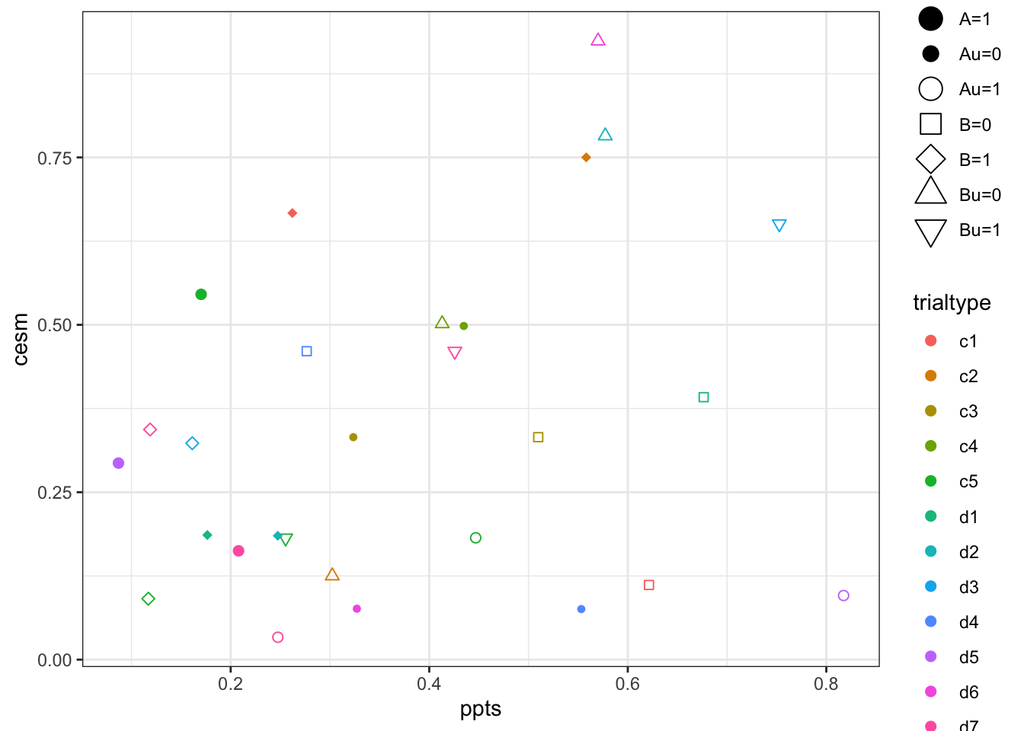

The correlation is 0.271.

### Parameter group 2) .5, .1, .5, .8.

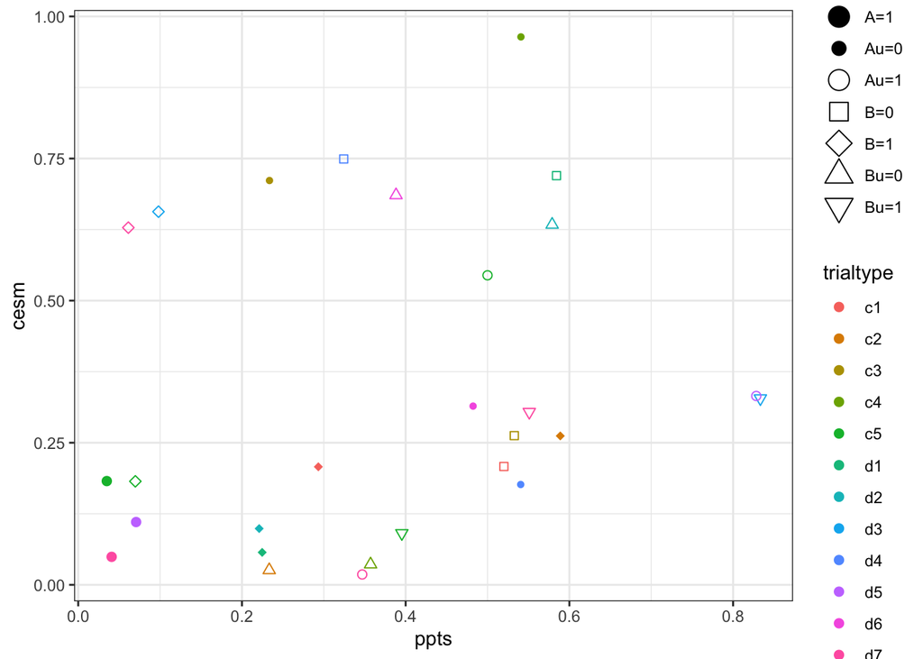

The correlation is 0.203.

### Parameter group 3) .1, .7, .8, .5.

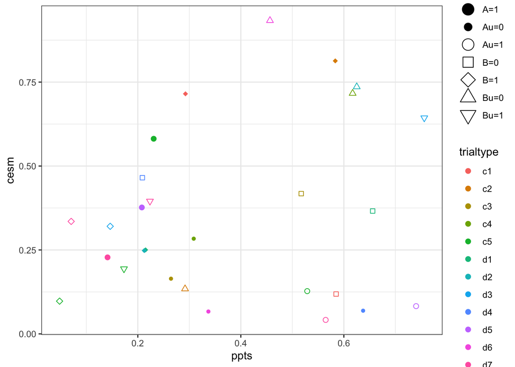

The correlation is 0.194.

Thus the average correlation across the three probability groups is 0.222666666666667